# LoanDataFromProsper Analysis

## by Azubuogu Peace Udoka

## Investigation Overview

The purpose of the analysis is to find the effects of APR, Loan original amount and ontime payments for charged off loans of unemployed borrowers.

## Dataset Overview

The loan data set contains 113,937 loans with 81 variables on each loan, including loan amount, borrower rate (or interest rate), current loan status, borrower income, and many others.

This [data dictionary](https://docs.google.com/spreadsheets/d/1gDyi_L4UvIrLTEC6Wri5nbaMmkGmLQBk-Yx3z0XDEtI/edit#gid=0) explains the variables in the data set.

## Distribution of Unemployed Borrowers Based On LoanStatus

A good number of unemployed borrowers from Prosper had their loans charged off.

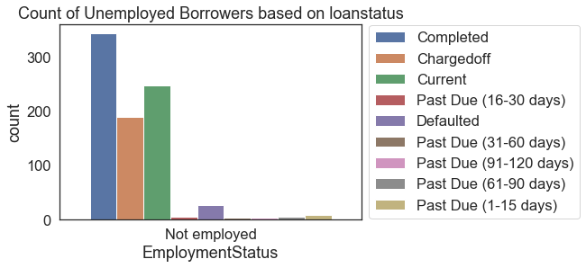

## Effect of Prosper Ratings and APR

The distribution below shows a negative correlation between the prosper rating and APR of a charged off loan. That is higher APRs for charged off loans were associated with lower prosper ratings. A low prosper rating already assumes a low risk and this could explain why lenders would charged off these loans.

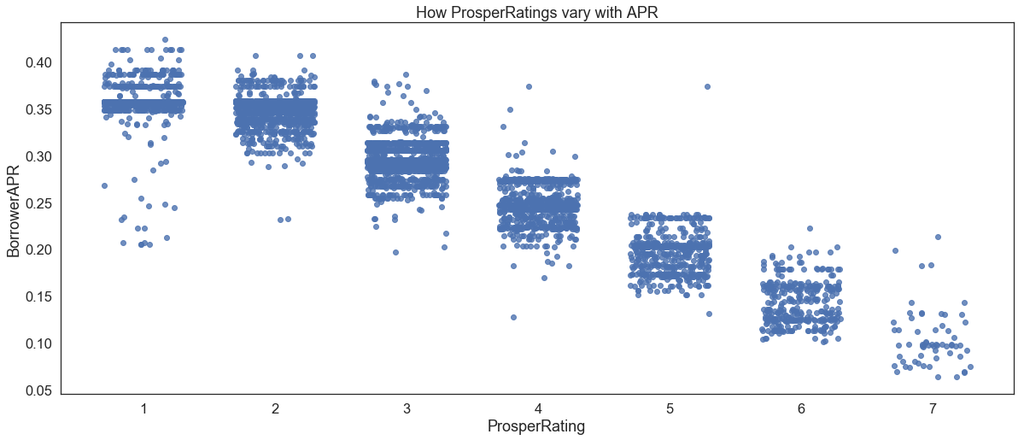

## Original Amount of Charged off Loans

To better understand why lenders chose to charge off loans of high APR despite the low risk, a plot of loan original amount is made and it can be seen that most of the charged off loans are actually loans of small amounts.

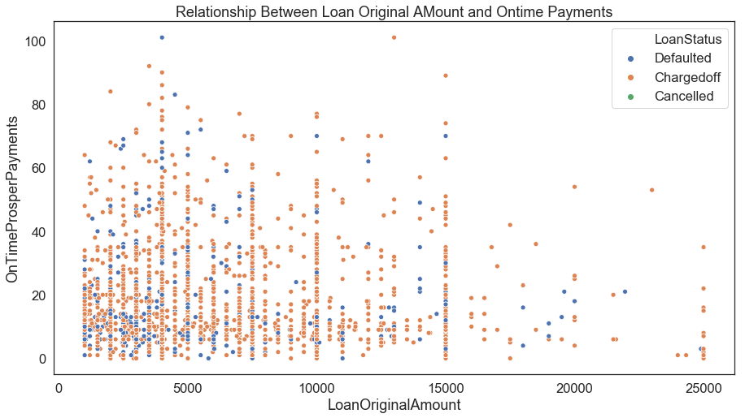

## Chargedoff Loans and OntimeProsperPayments

On further analysis, you can see that charged off loans are also associated with more total prosper loans and a higher range of Prosper payments made on time.

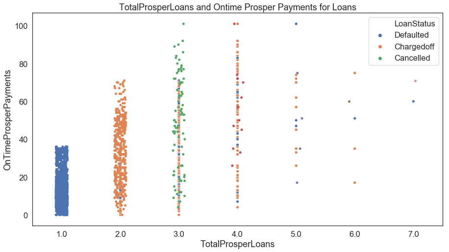